# How does life expectancy change over time for each continent?

The challenge:

Life expectancy for a country is the mean length of life over the people of that country. Using the variables life expectancy (`lifeExp`) and population (`pop`) of a country, from the `gapminder` dataset:

1. Derive a formula to compute the life expectancy of a continent (a group of countries).
2. Plot how life expectancy changed over time for each continent.
3. Do the same for the whole planet.

```r
gapminder
```

```
## # A tibble: 1,704 × 6
##    country     continent  year lifeExp      pop gdpPercap
##    <fct>       <fct>     <int>   <dbl>    <int>     <dbl>
##  1 Afghanistan Asia       1952    28.8  8425333      779.
##  2 Afghanistan Asia       1957    30.3  9240934      821.
##  3 Afghanistan Asia       1962    32.0 10267083      853.
##  4 Afghanistan Asia       1967    34.0 11537966      836.
##  5 Afghanistan Asia       1972    36.1 13079460      740.
##  6 Afghanistan Asia       1977    38.4 14880372      786.
##  7 Afghanistan Asia       1982    39.9 12881816      978.
##  8 Afghanistan Asia       1987    40.8 13867957      852.
##  9 Afghanistan Asia       1992    41.7 16317921      649.
## 10 Afghanistan Asia       1997    41.8 22227415      635.
## # ℹ 1,694 more rows
```

Each row is one country in one year, with its `lifeExp` and `pop` already recorded. There is no `lifeExp` column for a continent or for the world, we have to build one ourselves.

# 1 Part 1: deriving the formula

## 1.1 Why a simple average across countries is wrong

The naive approach is to just average `lifeExp` across all countries in a continent for a given year:

$$L_{\text{naive}} = \frac{1}{n}\sum_{i=1}^{n} L_i$$

This treats every country equally, no matter whether it has 1 million or 1 billion people. We can see this bias directly in the data: a tiny country gets exactly the same weight as a population giant.

```r
gapminder %>%
  filter(year == 2007, continent == "Asia") %>%
  select(country, pop, lifeExp) %>%
  arrange(desc(pop))
```

```
## # A tibble: 33 × 3
##    country            pop lifeExp
##    <fct>            <int>   <dbl>
##  1 China       1318683096    73.0
##  2 India       1110396331    64.7
##  3 Indonesia    223547000    70.6
##  4 Pakistan     169270617    65.5
##  5 Bangladesh   150448339    64.1
##  6 Japan        127467972    82.6
##  7 Philippines   91077287    71.7
##  8 Vietnam       85262356    74.2
##  9 Iran          69453570    71.0
## 10 Thailand      65068149    70.6
## # ℹ 23 more rows
```

China and India alone hold the overwhelming majority of Asia’s population in this table, yet a plain average of the `lifeExp` column would let Bahrain or Bhutan move the “continent average” just as much as China does. That can’t be right if we want a number that reflects how long the *typical person* on that continent lives.

## 1.2 The correct formula: a population-weighted mean

Life expectancy is a *rate* (years per person); population is an *extensive* quantity (a count of people). To combine a rate correctly across groups of different sizes, each country’s `lifeExp` must be weighted by its share of the continent’s total population:

$$L_{\text{continent}} =
\frac{\sum_{i=1}^{n} P_i \, L_i}{\sum_{i=1}^{n} P_i}$$

This is not an ad hoc fix, it falls directly out of what life expectancy means. If $L_i$ is the average lifespan of the $P_i$ people in country $i$, then $P_i L_i$ is the total number of life-years lived in that country. Summing $P_i L_i$ over every country in the continent and dividing by the continent’s total population gives the average lifespan across *every individual on the continent*, regardless of which country they live in, exactly $L_{\text{continent}}$ above. The same formula, applied over every country in the world instead of just one continent, gives the population-weighted life expectancy of the whole planet.

We implement this with a single `group_by()` + `summarise()`:

```r
weighted_lifeexp <- function(lifeExp, pop) {
  sum(lifeExp * pop) / sum(pop)
}
```

# 2 Part 2: life expectancy over time, by continent

```r
continent_lifeexp <- gapminder %>%
  group_by(continent, year) %>%
  summarise(
    lifeExp_weighted = weighted_lifeexp(lifeExp, pop),
    lifeExp_naive     = mean(lifeExp),
    pop_total         = sum(pop)
  ) %>%
  ungroup()

continent_lifeexp
```

```
## # A tibble: 60 × 5
##    continent  year lifeExp_weighted lifeExp_naive pop_total
##    <fct>     <int>            <dbl>         <dbl>     <dbl>
##  1 Africa     1952             38.8          39.1 237640501
##  2 Africa     1957             40.9          41.3 264837738
##  3 Africa     1962             43.1          43.3 296516865
##  4 Africa     1967             45.2          45.3 335289489
##  5 Africa     1972             47.2          47.5 379879541
##  6 Africa     1977             49.2          49.6 433061021
##  7 Africa     1982             51.0          51.6 499348587
##  8 Africa     1987             52.8          53.3 574834110
##  9 Africa     1992             53.4          53.6 659081517
## 10 Africa     1997             53.3          53.6 743832984
## # ℹ 50 more rows
```

## 2.1 The main plot

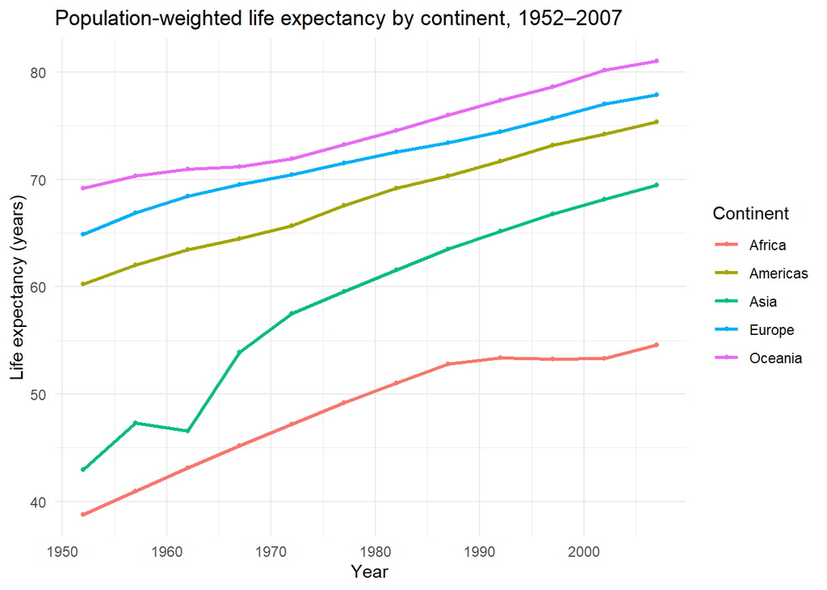

```r
ggplot(continent_lifeexp, aes(year, lifeExp_weighted, color = continent)) +
  geom_line(linewidth = 1) +
  geom_point(size = 1) +
  labs(
    title = "Population-weighted life expectancy by continent, 1952–2007",
    x = "Year",
    y = "Life expectancy (years)",
    color = "Continent"
  ) +
  theme_minimal()
```

The plot shows the pattern we’d expect from first principles: every continent trends upward over time, but Africa starts far below the others and the gap between continents narrows over the decades (convergence), rather than all the lines staying parallel.

## 2.2 Does weighting actually matter here?

We can check this directly by comparing the naive (unweighted) average to the population-weighted one, continent by continent:

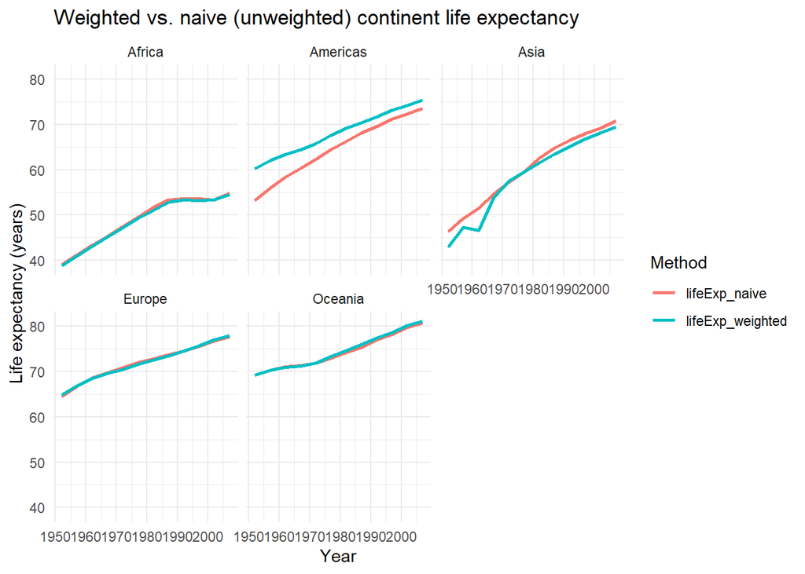

```r
continent_lifeexp %>%
  pivot_longer(
    cols = c(lifeExp_weighted, lifeExp_naive),
    names_to = "method",
    values_to = "lifeExp"
  ) %>%
  ggplot(aes(year, lifeExp, color = method)) +
  geom_line(linewidth = 1) +
  facet_wrap(~ continent) +
  labs(
    title = "Weighted vs. naive (unweighted) continent life expectancy",
    x = "Year", y = "Life expectancy (years)",
    color = "Method"
  ) +
  theme_minimal()
```

The two methods diverge most on continents made of countries with very unequal populations (Asia, dominated by China and India; the Americas, dominated by the US and Brazil), and they’re closest where countries are more similar in size. This confirms the reasoning from Part 1: weighting only matters when population is unevenly distributed across the group being aggregated.

## 2.3 A closer look: dips and shocks

Following the same approach as the “many simple models” case study, fitting a linear trend of `lifeExp` against `year` for each country and inspecting the residuals, reveals *where* the continent-level dips actually come from:

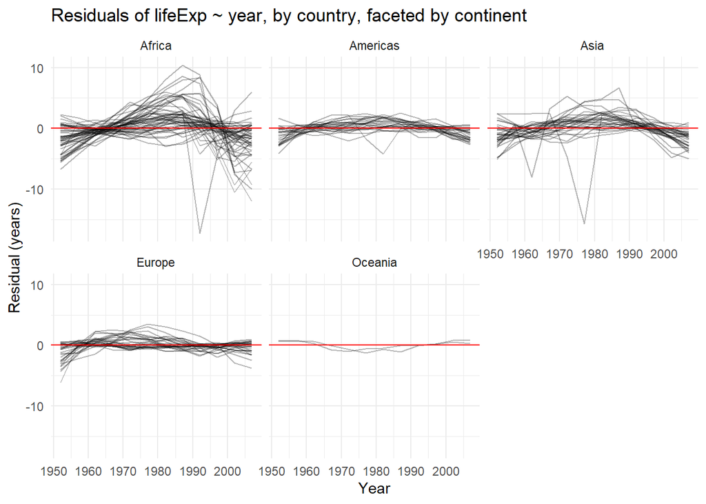

```r
country_models <- gapminder %>%
  group_by(country, continent) %>%
  nest() %>%
  mutate(
    model = map(data, ~ lm(lifeExp ~ year, data = .x)),
    data  = map2(data, model, ~ add_residuals(.x, .y))
  ) %>%
  unnest(data)

ggplot(country_models, aes(year, resid, group = country)) +
  geom_line(alpha = 0.3) +
  geom_hline(yintercept = 0, color = "red") +
  facet_wrap(~ continent) +
  labs(
    title = "Residuals of lifeExp ~ year, by country, faceted by continent",
    x = "Year", y = "Residual (years)"
  ) +
  theme_minimal()
```

Africa stands out from every other continent: several countries show a sharp mid-series collapse away from a simple linear improvement. This is the HIV/AIDS mortality shock of the 1990s, and because it hit several populous African countries at once, it is exactly the kind of event that shows up as a visible dent in the population-weighted continent curve above, even though it affected only one continent.

# 3 Part 3: the same formula for the whole planet

The planet is simply the special case of “one continent” containing every country on Earth. The identical weighted-mean formula applies, we just drop `continent` from the grouping:

```r
world_lifeexp <- gapminder %>%
  group_by(year) %>%
  summarise(
    lifeExp_weighted = weighted_lifeexp(lifeExp, pop),
    pop_total         = sum(pop)
  )

world_lifeexp
```

```
## # A tibble: 12 × 3
##     year lifeExp_weighted  pop_total
##    <int>            <dbl>      <dbl>
##  1  1952             48.9 2406957150
##  2  1957             52.1 2664404580
##  3  1962             52.3 2899782974
##  4  1967             57.0 3217478384
##  5  1972             59.5 3576977158
##  6  1977             61.2 3930045807
##  7  1982             62.9 4289436840
##  8  1987             64.4 4691477418
##  9  1992             65.6 5110710260
## 10  1997             66.8 5515204472
## 11  2002             67.8 5886977579
## 12  2007             68.9 6251013179
```

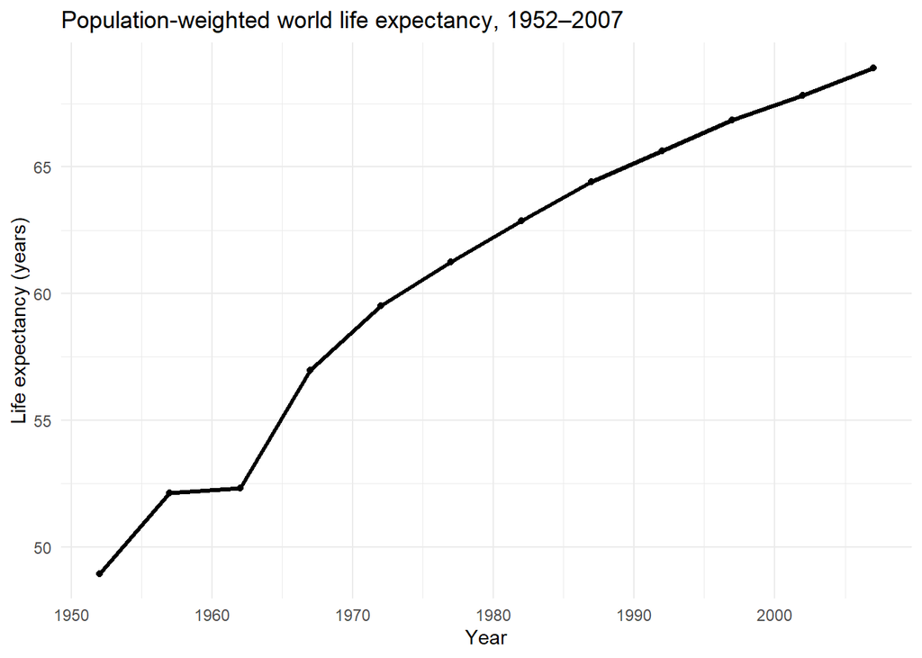

```r
ggplot(world_lifeexp, aes(year, lifeExp_weighted)) +
  geom_line(linewidth = 1.2, color = "black") +
  geom_point(size = 1.5, color = "black") +
  labs(
    title = "Population-weighted world life expectancy, 1952–2007",
    x = "Year", y = "Life expectancy (years)"
  ) +
  theme_minimal()
```

## 3.1 Checking internal consistency: country-level vs. continent-level aggregation

The weighted-mean formula has a useful consistency property (a form of the law of total expectation): we should get the same world average whether we aggregate directly over every country, or aggregate continents first and then combine those continent totals. Let’s verify this numerically:

```r
world_from_continents <- continent_lifeexp %>%
  group_by(year) %>%
  summarise(lifeExp_from_continents = weighted_lifeexp(lifeExp_weighted, pop_total))

world_lifeexp %>%
  left_join(world_from_continents, by = "year") %>%
  mutate(difference = lifeExp_weighted - lifeExp_from_continents)
```

```
## # A tibble: 12 × 5
##     year lifeExp_weighted  pop_total lifeExp_from_continents difference
##    <int>            <dbl>      <dbl>                   <dbl>      <dbl>
##  1  1952             48.9 2406957150                    48.9   0
##  2  1957             52.1 2664404580                    52.1   0
##  3  1962             52.3 2899782974                    52.3   0
##  4  1967             57.0 3217478384                    57.0   0
##  5  1972             59.5 3576977158                    59.5  -7.11e-15
##  6  1977             61.2 3930045807                    61.2   0
##  7  1982             62.9 4289436840                    62.9   0
##  8  1987             64.4 4691477418                    64.4   0
##  9  1992             65.6 5110710260                    65.6   0
## 10  1997             66.8 5515204472                    66.8   0
## 11  2002             67.8 5886977579                    67.8   0
## 12  2007             68.9 6251013179                    68.9   0
```

The `difference` column is (up to floating-point rounding) zero for every year: aggregating country $\to$ world directly and aggregating country $\to$ continent $\to$ world give identical results, exactly as the formula predicts.

## 3.2 Comparing the world curve to the continents

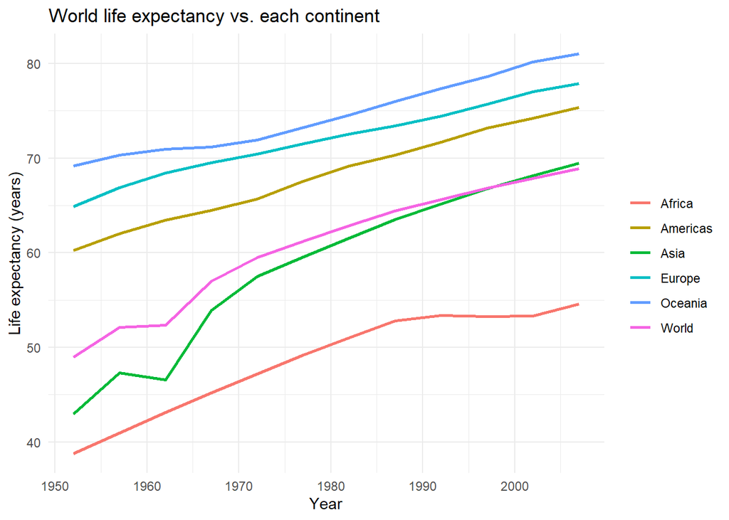

```r
continent_lifeexp %>%
  select(continent, year, lifeExp_weighted) %>%
  bind_rows(
    world_lifeexp %>% mutate(continent = "World") %>%
      select(continent, year, lifeExp_weighted)
  ) %>%
  ggplot(aes(year, lifeExp_weighted, color = continent)) +
  geom_line(linewidth = 1) +
  labs(
    title = "World life expectancy vs. each continent",
    x = "Year", y = "Life expectancy (years)", color = ""
  ) +
  theme_minimal()
```

# 4 Conclusion